# Analysis of TEDS_2016 Dataset

## Load necessary libraries

```r
library(haven) # For reading Stata data files
library(MASS)  # For ordinal logistic regression
library(vcd)   # For categorical data
```

## Read the dataset into R

```r
TEDS_2016 <- read_stata("https://github.com/datageneration/home/blob/master/DataProgramming/data/TEDS_2016.dta?raw=true")
```

## Data Preprocessing

### Calculate Missing Values

```r
na_count <- sapply(TEDS_2016, function(y) sum(is.na(y)))
na_count_votetsai <- sum(is.na(TEDS_2016$votetsai))
```

### Examine Unique Values

```r
unique(TEDS_2016$Tondu)
```

```
## <labelled<double>[7]>: Position on unification and independence
## [1] 3 5 9 4 6 2 1
##
## Labels:
##  value                                                              label
##      1                                              Immediate unification
##      2                    Maintain the status quo,move toward unification
##      3 Maintain the status quo, decide either unification or independence
##      4                                    Maintain the status quo forever
##      5                   Maintain the status quo,move toward independence
##      6                                             Immediate independence
##      9                                                        Nonresponse
```

```r
summary(TEDS_2016$Tondu)
```

```
##    Min. 1st Qu.  Median    Mean 3rd Qu.    Max.
##   1.000   3.000   4.000   4.127   5.000   9.000
```

### Histogram of ‘Tondu’

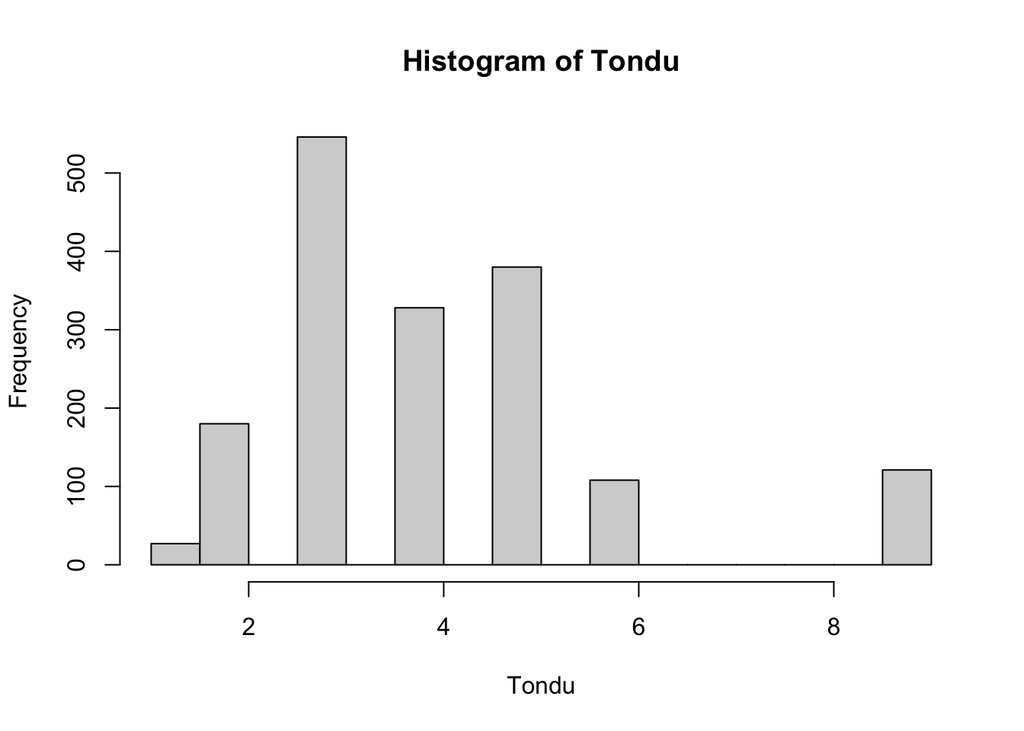

```r
hist(TEDS_2016$Tondu, main = "Histogram of Tondu", xlab = "Tondu")
```

### Check Binary Distribution

```r
table(TEDS_2016$female)
```

```
##
##   0   1
## 868 822
```

### Convert Numerics to Factors

```r
TEDS_2016$female <- factor(TEDS_2016$female, levels = c(0, 1), labels = c("Male", "Female"))
TEDS_2016$DPP <- factor(TEDS_2016$DPP)

binary_columns <- sapply(TEDS_2016, function(x) all(x %in% c(0, 1, NA)))
TEDS_2016[, binary_columns] <- lapply(TEDS_2016[, binary_columns], function(x) factor(x, levels = c(0, 1)))
```

### Impute Missing Values

```r
# Numerical variables
numerical_columns <- sapply(TEDS_2016, is.numeric) & !binary_columns
TEDS_2016[, numerical_columns] <- lapply(TEDS_2016[, numerical_columns], function(x) {
  ifelse(is.na(x), mean(x, na.rm = TRUE), x)
})

# Categorical variables
categorical_columns <- sapply(TEDS_2016, is.factor)
TEDS_2016[, categorical_columns] <- lapply(TEDS_2016[, categorical_columns], function(x) {
  freq_table <- table(x)
  mode_value <- names(which.max(freq_table))
  x[is.na(x)] <- mode_value
  factor(x, levels = levels(x))
})
```

## Analysis

### Frequency Table for ‘Tondu_with_no_response’

```r
TEDS_2016$Tondu_numeric <- as.numeric(TEDS_2016$Tondu)
TEDS_2016$Tondu_with_no_response <- factor(TEDS_2016$Tondu_numeric,
                                           levels = c(1, 2, 3, 4, 5, 6, 9),
                                           labels = c("Immediate unification",
                                                      "Maintain the status quo, move toward unification",
                                                      "Maintain the status quo, decide either unification or independence",
                                                      "Maintain the status quo forever",
                                                      "Maintain the status quo, move toward independence",
                                                      "Immediate independence",
                                                      "No response"))
tondu_freq_table <- table(TEDS_2016$Tondu_with_no_response)
tondu_freq_table
```

```
##
##                                              Immediate unification
##                                                                 27
##                   Maintain the status quo, move toward unification
##                                                                180
## Maintain the status quo, decide either unification or independence
##                                                                546
##                                    Maintain the status quo forever
##                                                                328
##                  Maintain the status quo, move toward independence
##                                                                380
##                                             Immediate independence
##                                                                108
##                                                        No response
##                                                                121
```

### Ordinal Logistic Regression

```r
TEDS_2016 <- subset(TEDS_2016, !is.na(Tondu) & Tondu != 9 & !is.na(votetsai))
TEDS_2016$Tondu <- factor(TEDS_2016$Tondu, levels = c(1, 2, 3, 4, 5, 6),
                          labels = c("Immediate unification",
                                     "Maintain the status quo, move toward unification",
                                     "Maintain the status quo, decide either unification or independence",
                                     "Maintain the status quo forever",
                                     "Maintain the status quo, move toward independence",
                                     "Immediate independence"),
                          ordered = TRUE)
ordinal_model <- polr(Tondu ~ female + DPP + age + income + edu + Taiwanese + Econ_worse,
                      data = TEDS_2016)
```

### Goodman and Kruskal’s Gamma Coefficient

```r
gamma_age <- assocstats(table(TEDS_2016$age, TEDS_2016$Tondu_numeric))$gamma
gamma_income <- assocstats(table(TEDS_2016$income, TEDS_2016$Tondu_numeric))$gamma
gamma_edu <- assocstats(table(TEDS_2016$edu, TEDS_2016$Tondu_numeric))$gamma
gamma_results <- list(age_gamma = gamma_age, income_gamma = gamma_income, edu_gamma = gamma_edu)
```

### Chi-Square Test of Independence

```r
TEDS_2016$DPP <- factor(TEDS_2016$DPP)
TEDS_2016$Taiwanese <- factor(TEDS_2016$Taiwanese)
TEDS_2016$Econ_worse <- factor(TEDS_2016$Econ_worse)

chi_square_DPP <- chisq.test(table(TEDS_2016$DPP, TEDS_2016$Tondu), simulate.p.value = TRUE)
chi_square_Taiwanese <- chisq.test(table(TEDS_2016$Taiwanese, TEDS_2016$Tondu), simulate.p.value = TRUE)
chi_square_Econ_worse <- chisq.test(table(TEDS_2016$Econ_worse, TEDS_2016$Tondu), simulate.p.value = TRUE)
chi_square_results <- list(DPP = chi_square_DPP, Taiwanese = chi_square_Taiwanese, Econ_worse = chi_square_Econ_worse)
```

### Logistic Regression

```r
TEDS_2016 <- subset(TEDS_2016, !is.na(votetsai))
logistic_model <- glm(votetsai ~ female + DPP + age + income + edu + Taiwanese + Econ_worse,
                      family = binomial(link = "logit"), data = TEDS_2016)
summary(logistic_model)
```

```
##
## Call:
## glm(formula = votetsai ~ female + DPP + age + income + edu +
##     Taiwanese + Econ_worse, family = binomial(link = "logit"),
##     data = TEDS_2016)
##
## Coefficients:
##               Estimate Std. Error z value Pr(>|z|)
## (Intercept)   1.490842   0.433296   3.441  0.00058 ***
## femaleFemale -0.404225   0.133554  -3.027  0.00247 **
## DPP1          2.963318   0.259074  11.438  < 2e-16 ***
## age          -0.023759   0.005080  -4.677 2.91e-06 ***
## income       -0.003661   0.025452  -0.144  0.88563
## edu          -0.175804   0.060354  -2.913  0.00358 **
## Taiwanese1    1.038279   0.135487   7.663 1.81e-14 ***
## Econ_worse1   0.358628   0.132925   2.698  0.00698 **
## ---
## Signif. codes:  0 '***' 0.001 '**' 0.01 '*' 0.05 '.' 0.1 ' ' 1
##
## (Dispersion parameter for binomial family taken to be 1)
##
##     Null deviance: 1898.4  on 1568  degrees of freedom
## Residual deviance: 1398.2  on 1561  degrees of freedom
## AIC: 1414.2
##
## Number of Fisher Scoring iterations: 6
```

### More Chi-Square Tests

```r
chi_square_female <- chisq.test(table(TEDS_2016$female, TEDS_2016$votetsai), simulate.p.value = TRUE)
chi_square_DPP <- chisq.test(table(TEDS_2016$DPP, TEDS_2016$votetsai), simulate.p.value = TRUE)
chi_square_results_votetsai <- list(female = chi_square_female, DPP = chi_square_DPP)
```

## Visualization

### Bar Chart for ‘Tondu_with_no_response’

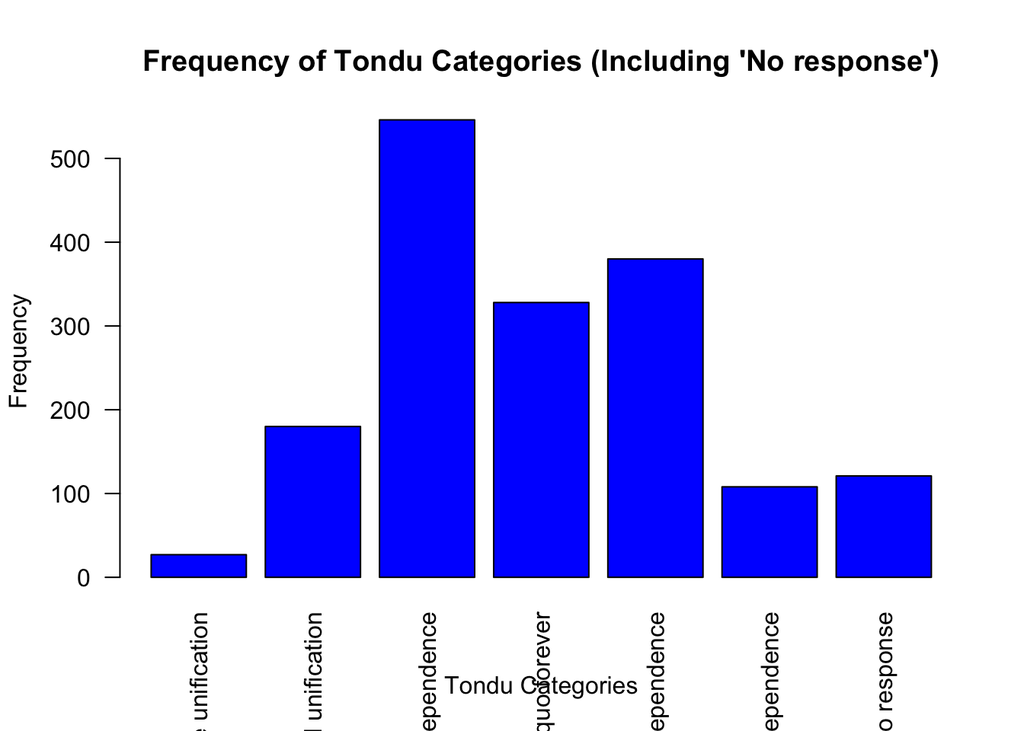

```r
barplot(tondu_freq_table,
        main = "Frequency of Tondu Categories (Including 'No response')",
        xlab = "Tondu Categories",
        ylab = "Frequency",
        las = 2,
        col = "blue")
```

### Boxplot of Age by Tondu

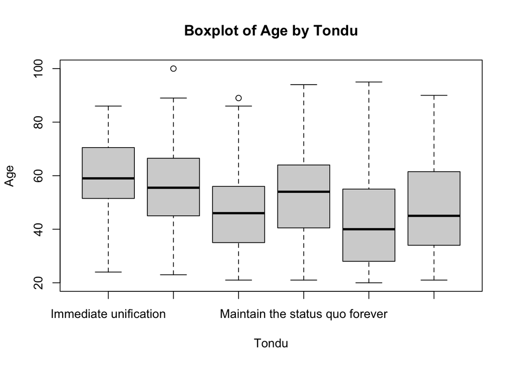

```r
boxplot(age ~ Tondu, data = TEDS_2016, main = "Boxplot of Age by Tondu", xlab = "Tondu", ylab = "Age")
```

### Bar Chart of Gender Vote by Tondu

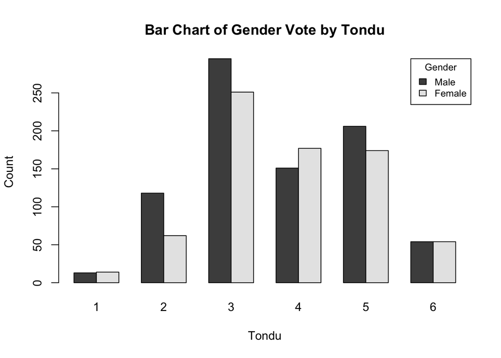

```r
barplot(table(TEDS_2016$female, TEDS_2016$Tondu_numeric),
        beside = TRUE,
        legend = c("Male", "Female"),
        main = "Bar Chart of Gender Vote by Tondu",
        xlab = "Tondu",
        ylab = "Count",
        args.legend = list(title = "Gender", x = "topright", cex = 0.8))
```

### Bar Chart of Gender by Vote for Tsai

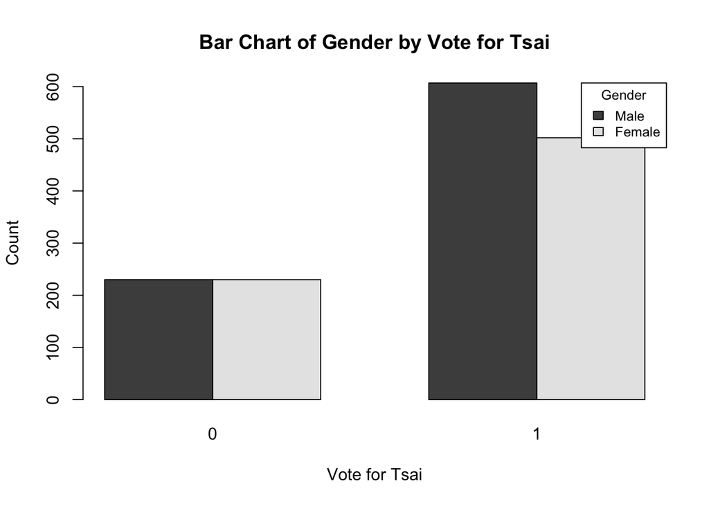

```r
barplot(table(TEDS_2016$female, TEDS_2016$votetsai),
        beside = TRUE,
        legend = c("Male", "Female"),
        main = "Bar Chart of Gender by Vote for Tsai",
        xlab = "Vote for Tsai",
        ylab = "Count",
        args.legend = list(title = "Gender", x = "topright", cex = 0.8))
```

## Results and Discussion

Analysis of the results: - **(Intercept)**: The estimated log-odds of `votetsai` being 1 (versus 0) when all predictors are at their reference levels is 1.490842. This is statistically significant with a p-value of 0.00058.

- **femaleFemale**: Being female is associated with a decrease in the log-odds of `votetsai` by -0.404225 compared to being male (the reference category). This effect is statistically significant (p = 0.00247).
- **DPP1**: Affiliation with DPP (Democratic Progressive Party) is associated with an increase in the log-odds of `votetsai` by 2.963318 compared to non-affiliation (the reference category). This is highly statistically significant (p < 2e-16).
- **age**: Each additional year of age is associated with a decrease in the log-odds of `votetsai` by -0.023759. This effect is statistically significant (p = 2.91e-06).
- **income**: The coefficient for income is not statistically significant (p = 0.88563), suggesting that income does not have a significant effect on the log-odds of `votetsai`.
- **edu**: Higher education levels are associated with a decrease in the log-odds of `votetsai` by -0.175804. This effect is statistically significant (p = 0.00358).
- **Taiwanese1**: Identifying as Taiwanese is associated with an increase in the log-odds of `votetsai` by 1.038279. This effect is highly statistically significant (p = 1.81e-14).
- **Econ_worse1**: Believing the economy has gotten worse is associated with an increase in the log-odds of `votetsai` by 0.358628. This effect is statistically significant (p = 0.00698).

The model’s AIC (Akaike Information Criterion) is 1414.2, which can be used for model comparison purposes. The lower the AIC, the better the model fits the data while penalizing for complexity.

The null deviance and residual deviance indicate how well the model fits the data compared to a null model with only the intercept. The significant reduction from the null deviance to the residual deviance shows that the predictors improve the model fit.

Overall, the model suggests that gender, DPP affiliation, age, education level, Taiwanese identity, and perception of the economy are significant predictors of `votetsai`. Income is not a significant predictor in this model.

[output not shown]